**FFT Practice**

By Prof. Seungchul Lee  
http://iai.postech.ac.kr/  
Industrial AI Lab at POSTECH

Table of Contents

# 1. FFT with Sampling Frequency

## 1.1. Implementing FFT routine

```matlab
Fs = 1000;            % Sampling frequency
T = 1/Fs;             % Sampling period (or sampling interval)

N = 5000;             % Total data points (signal length)

t = (0:N-1)*T;        % Time vector (time range)

k = [0:N-1];          % vector from 0 to N-1
f = (Fs/N)*k;         % frequency range
```

$$x[n] = 2 \cos(2 \pi 60 t) \implies f = 60$$

You can think this signal as a vibration signal from a rotating machinery with 60 Hz (or 60 $\times$ 60 = 3600 rpm)

```matlab
x = 2*cos(2*pi*60*t);
xn = x + 1*randn(size(t));
```

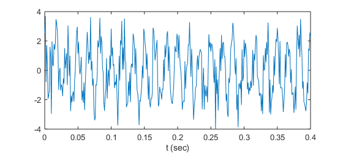

```matlab
%plot -s 560,250

plot(t,xn),
xlim([0,0.4])
xlabel('t (sec)')
```

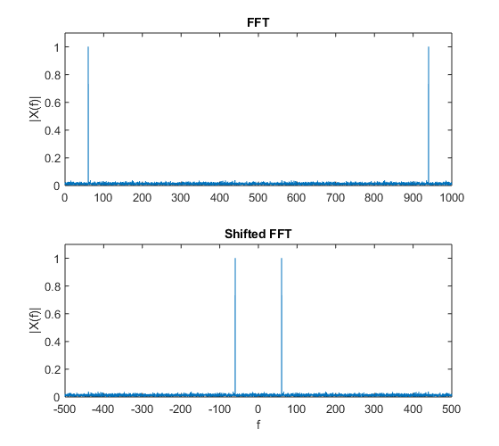

```matlab
%plot -s 560,500

% original fft

xnt = fft(xn)/N;
xntshift = fftshift(xnt);

kr = [0:N/2-1 -N/2:-1];
fr = (Fs/N)*kr;
fs = fftshift(fr);

subplot(2,1,1), plot(f,abs(xnt)), ylabel('|X(f)|'), title('FFT'), ylim([0,1.1])
subplot(2,1,2), plot(fs,abs(xntshift)), xlabel('f'), ylabel('|X(f)|'), title('Shifted FFT'), ylim([0,1.1])
```

## 1.2. Single-sided FFT (or Positive FFT)

- Only want the first half of the FFT, since the last is redundant (symmetric)
- 2 $\times$ amplitude except the DC component

```matlab
% single-sides fft

xnt = fft(xn)/N;
xntss = xnt(1:N/2+1);
xntss(2:end-1) = 2*xntss(2:end-1);
```

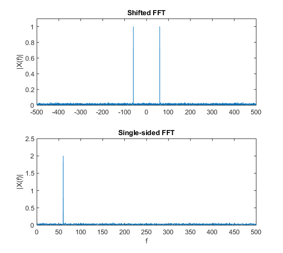

```matlab
%plot -s 560,500

fss = f(1:N/2+1);

subplot(2,1,1), plot(fs,abs(xntshift)), ylabel('|X(f)|'), title('Shifted FFT'), ylim([0,1.1])
subplot(2,1,2), plot(fss,abs(xntss)), xlabel('f'), ylabel('|X(f)|'), title('Single-sided FFT')
```

# 2. Extract Amplitude of the Specific Frequency

For instance,

$$X_{\text{feature vector}} = \text{amplitude at } 1X$$

```
X1 =

    2.0040
```

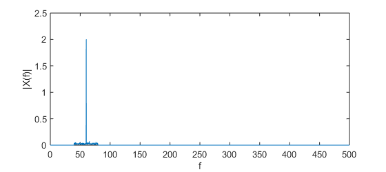

```matlab
%plot -s 560,250

amplitude = abs(xntss);

f1 = 60;
c = 20;

filter01 = zeros(1,length(fss));
filter01([ceil(N/Fs*(f1-c)):ceil(N/Fs*(f1+c))]) = 1;

X1 = max(amplitude.*filter01)

plot(fss,amplitude.*filter01), xlabel('f'), ylabel('|X(f)|')
```

# 3. Envelope Analysis

## 3.1. Beats

```matlab
%%html
<center><iframe src="https://www.youtube.com/embed/7YEyMLX3sD8?rel=0"
width="420" height="315" frameborder="0" allowfullscreen></iframe></center>
```

[video not shown]

$$\cos(2 \pi f_1 t) + \cos(2 \pi f_2 t) = 2 \cos \left(2 \pi \frac{f_1 + f_2}{2} t \right) \cos \left(2 \pi \frac{f_1 - f_2}{2} t \right) $$

```matlab
Fs = 44100;            % Sampling frequency
T = 1/Fs;             % Sampling period (or sampling interval)

N = 5*Fs;             % Total data points (signal length)

t = (0:N-1)*T;        % Time vector (time range)

k = [0:N-1];          % vector from 0 to N-1
f = (Fs/N)*k;         % frequency range
```

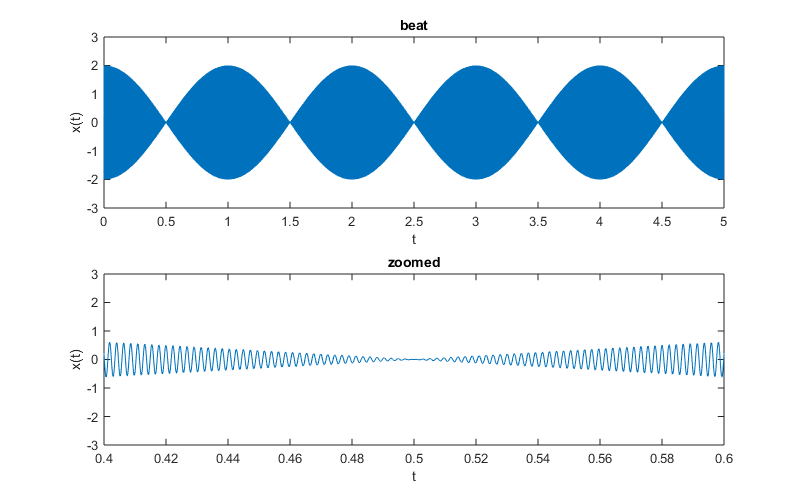

```matlab
%plot -s 800,500

x = cos(2*pi*440*t) + cos(2*pi*441*t);

subplot(2,1,1), plot(t,x), xlabel('t'), ylabel('x(t)'), title('beat'), ylim([-3,3])
subplot(2,1,2), plot(t,x), xlabel('t'), ylabel('x(t)'), title('zoomed'), ylim([-3,3]), xlim([0.4,0.6])

sound(x,Fs)
```

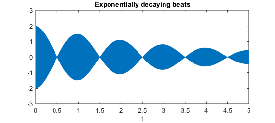

```matlab
%plot -s 560,250

xexp = x.*exp(-0.3*t);

plot(t,xexp), xlabel('t'), title('Exponentially decaying beats'), ylim([-3,3])

sound(xexp,Fs)
```

## 3.2. Modulation and Demodulation

Modulation is the process of varying one or more properties of a periodic waveform, called the carrier signal, with a modulating signal that typically contains information to be transmitted. Most radio systems in the 20th century used frequency modulation (FM) or amplitude modulation (AM) to make the carrier carry the radio broadcast.

[figure not shown]

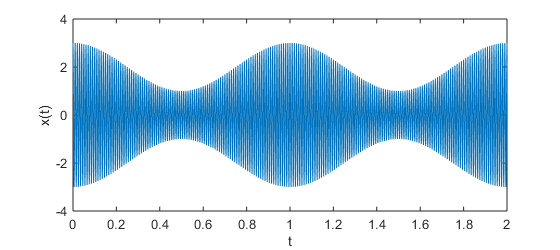

```matlab
%plot -s 560,250

Fs = 1000;            % Sampling frequency
T = 1/Fs;             % Sampling period (or sampling interval)

N = Fs*5;             % Total data points (signal length)

t = (0:N-1)*T;        % Time vector (time range)

k = [0:N-1];          % vector from 0 to N-1
f = (Fs/N)*k;         % frequency range

sig = cos(2*pi*1*t) + 2;
carrier = cos(2*pi*100*t);

x = sig.*carrier;

plot(t,x), xlabel('t'), ylabel('x(t)'), xlim([0,2]), ylim([-4,4])
sound(x,Fs)
```

$$ \begin{align*} x[t] &= \cos (2\pi f_H t )(2 + \cos(2 \pi f_L t))\\ \\ &=2\cos(2\pi f_H t) + \frac{1}{2}\cos(2 \pi (f_H - f_L) t) + \frac{1}{2}\cos(2 \pi (f_H + f_L) t) \end{align*}$$

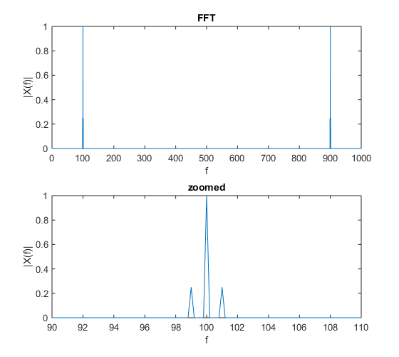

```matlab
%plot -s 560,500

xt = fft(x)/N;

subplot(2,1,1), plot(f,abs(xt)), xlabel('f'), ylabel('|X(f)|'), title('FFT')
subplot(2,1,2), plot(f,abs(xt)), xlabel('f'), ylabel('|X(f)|'), title('zoomed'), xlim([90,110])
```

Hilbert Transform

- Do not worry about the equation. It will give us the envelope of a signal

$$H(u(t)) = \frac{1}{\pi} \int_{-\infty}^{\infty} \frac{u(\tau)}{t-\tau} d\tau$$

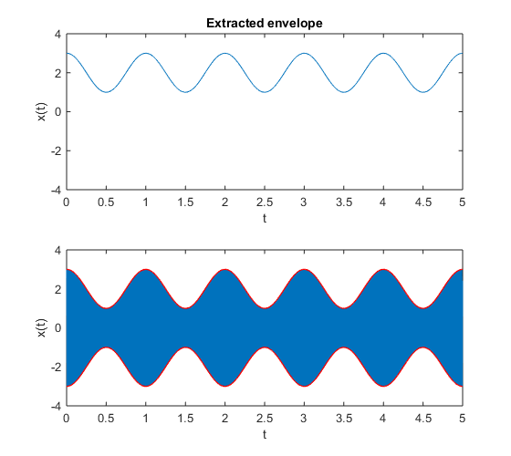

```matlab
%plot -s 560,500

% extract envelope using Hilbert transform

xe = abs(hilbert(x));

subplot(2,1,1), plot(t,xe), xlabel('t'), ylabel('x(t)'), title('Extracted envelope'), ylim([-4,4])
subplot(2,1,2), plot(t,x), hold on, plot(t,[-1;1]*xe,'r','LineWidth',1), hold off, , xlabel('t'), ylabel('x(t)'), ylim([-4,4])
```

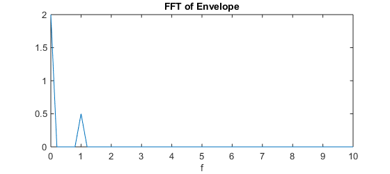

```matlab
%plot -s 560,250

xet = fft(xe)/N;

plot(f,abs(xet)), xlabel('f'), title('FFT of Envelope'), xlim([0,10])
```

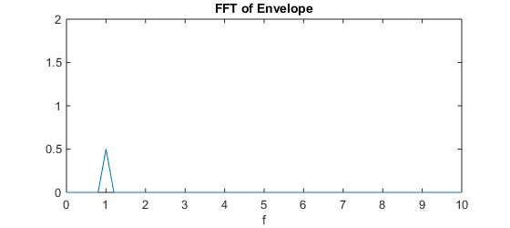

```matlab
%plot -s 560,250

xez = xe - mean(xe); % remove dc offset
xezt = fft(xez)/N;

plot(f,abs(xezt)), xlabel('f'), title('FFT of Envelope'), xlim([0,10]), ylim([0,2])
```

# 4. STFT (Short-Time Fourier Transform)

```matlab
Fs = 2^10;            % Sampling frequency
T = 1/Fs;             % Sampling period (or sampling interval)

N = Fs*2;             % Total data points (signal length)

t = (0:N-1)*T;        % Time vector (time range)

k = [0:N-1];          % vector from 0 to N-1
f = (Fs/N)*k;         % frequency range

x1 = cos(2*pi*50*t);
x2 = cos(2*pi*100*t);

x = zeros(size(t));
x(1:N/2) = x1(1:N/2);
x(N/2+1:end) = x2(N/2+1:end);
```

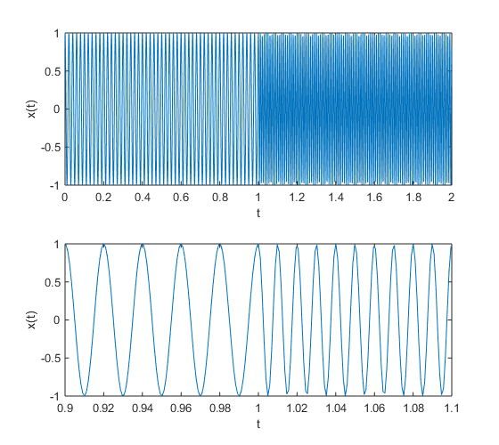

```matlab
%plot -s 560,500

subplot(2,1,1), plot(t,x), xlabel('t'), ylabel('x(t)')
subplot(2,1,2), plot(t,x), xlabel('t'), ylabel('x(t)'), xlim([0.9,1.1])
```

FFT does not provide time information of the signal.

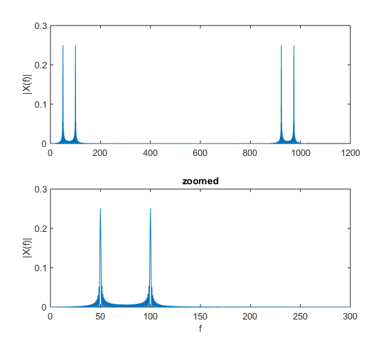

```matlab
%plot -s 560,500

xt = fft(x)/N;
subplot(2,1,1), plot(f,abs(xt)), ylabel('|X(f)|')
subplot(2,1,2), plot(f,abs(xt)), xlabel('f'), ylabel('|X(f)|'), title('zoomed'), xlim([0,300])
```

- The spectral content of speech changes over time (non-stationary)
  - As an example, formants change as a function of the spoken phonemes
  - Applying the DFT over a long window does not reveal transitions in spectral content
- To avoid this issue, we apply the DFT over short periods of time
  - For short enough windows, speech can be considered to be stationary
  - Remember, though, that there is a time-frequency tradeoff here!

[figure not shown]

- Matlab function `spectrogram` is useful for easily computing STFTs

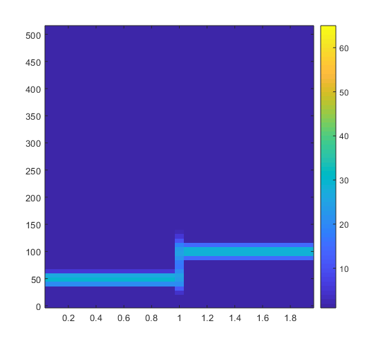

```matlab
windowsize = 2^7;
window = hanning(windowsize);
nfft = windowsize;
noverlap = windowsize/2;

[S,F,T] = spectrogram(x,window,noverlap,nfft,Fs);

image(T,F,20*log10(abs(S)));
set(gca,'ydir','normal'); colorbar
```

```matlab
%%javascript
$.getScript('https://kmahelona.github.io/ipython_notebook_goodies/ipython_notebook_toc.js')
```